# Base Real Estate Demand Model

*Shingai Samudzi (@samudzi)*

*June 12,2019*

# Prerequisites

To get started, you will need to install all of the necessary libraries, as well as import the dataset from Looker

```r
#Make sure that the Looker Connection is initialized
source(file="~/Projects/initializeLooker.R")

setwd("~/Projects/DemandModeling")
#Load predictive R library
source(file="lib/predictiveR2.R")
source(file="lib/crossvalidation.R")

#Load all of the key libraries
library (plyr)
library(dplyr)
library(quantmod)
library(purrr)
library(data.table)
library(tidyr)
library(MVLM)
library(car)
library(ggplot2)
library(GGally)
library(scatterplot3d)
library(rrr)
library(caret)
library(leaps)

#pull data from the Looker API
base_data <- sdk$runLook(lookId = 51)
```

# Preprocessing Data

We will now massage our data into the shape we want it for analysis

```r
#Looker API returns data as list of lists.  Convert master list into dataframe -- this issue is fixed in Maxie's dev branch of the LookR package, commenting out here:
#base_df <- as.data.frame(do.call(rbind, lapply(base_data, as.vector)))
#base_df[base_df == "NULL"] <- NA

#Add Column Headers

headers <- c("zipcode","city","state","x.median_income","x.median_home_value","x.Five_yr_unit_growth_rate","x.total_units","x.Three_yr_HPI_percent_change","x.Ten_yr_HPI_percent_change","x.percent_usable_land","x.median_net_wealth","x.percent_of_households_renters","y.HPI","x.new_units_per_capita_over_Five_yrs","y.One_yr_HPI_percent_change","x.One_yr_pop_change","x.Three_yr_pop_change","y.Five_yr_pop_change")

names(base_data) <- headers

#un-nest the second level of lists -- commenting out, see comment above
#base_df <- unnest(base_df)

#Remove text-only columns
base_df <- na.omit(select(base_data,-1,-2,-3))

#check data types
str(base_df)
```

The Looker API returns all data as strings, so we need to convert the dataframe to numeric type.

```r
base_df2 <- mutate_all(base_df, function(x) as.numeric(as.character(x)))
str(base_df2)
```

# Building Simple Linear Regression Models

Our goal is a multivariate regression model, where HPI and most recent 1 year HPI % change are the response variables, and the others are the predictors.

The first step in the process is some simple data exploration. Running pairs is a good way to find which variables are highly correlated in order to reduce total number of variables in the model

```r
summary(base_df2)
pairs(base_df2)
```

We then jump into some visual exploration. Creating a plot matrix to see how variables interrelate

```r
model_plot <- ggpairs(data=base_df2, columns=1:11, title="Real Estate Demand Variables", progress=NULL)

#second form of variable analysis to assess correlations between predictor variables

model_x <- base_df2 %>%
    select(starts_with("x"))
model_y <- base_df2 %>%
    select(starts_with("y"))

GGally::ggcorr(model_x)
GGally::ggcorr(model_y)
```

Results of the visualization from model_plot above:

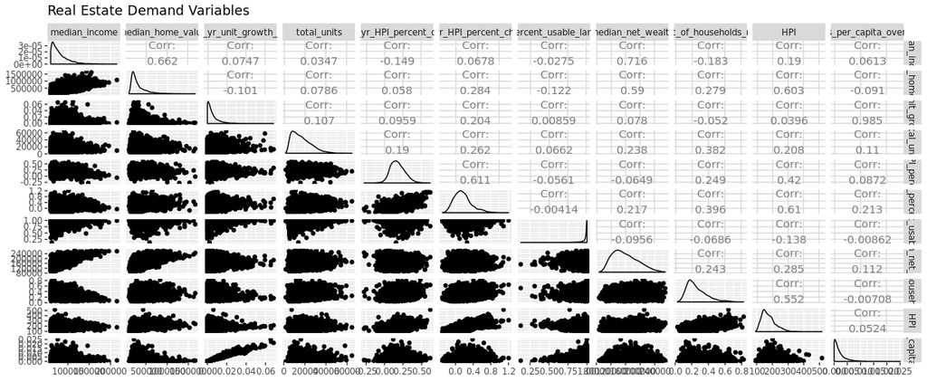

The results in the visual analysis suggest that with a correlation of 0.985, Five_yr_unit_growth_rate and new_units_per_capita_over_Five_yrs do not add unique strength to the model, and one can be excluded.

There are also strong correlations between median_income and median_net_wealth, as well as median_income and median_home_value. We can eliminate variables there as well.

```r
model_x2 <- na.omit(select(model_x,-2,-3,-4,-8))
```

[output not shown]

## Linear Regression Models

Then we run our multivariate regression to build the models for our H1 and H2 hypotheses

```r
h2 <-lm(y.HPI ~ x.median_income + x.new_units_per_capita_over_Five_yrs + x.percent_usable_land + x.Ten_yr_HPI_percent_change, data = base_df2)
summary(h2)
```

```
Call:
lm(formula = y.HPI ~ x.median_income + x.new_units_per_capita_over_Five_yrs +
    x.percent_usable_land + x.Ten_yr_HPI_percent_change, data = base_df2)

Residuals:
     Min       1Q   Median       3Q      Max
-150.657  -23.633   -5.532   20.500  193.868

Coefficients:
                                       Estimate Std. Error t value Pr(>|t|)
(Intercept)                           2.292e+02  6.433e+00  35.635   <2e-16 ***
x.median_income                       3.101e-04  2.420e-05  12.814   <2e-16 ***
x.new_units_per_capita_over_Five_yrs -1.740e+03  2.031e+02  -8.566   <2e-16 ***
x.percent_usable_land                -9.916e+01  6.412e+00 -15.465   <2e-16 ***
x.Ten_yr_HPI_percent_change           1.417e+02  2.285e+00  62.016   <2e-16 ***
---
Signif. codes:  0 ‘***’ 0.001 ‘**’ 0.01 ‘*’ 0.05 ‘.’ 0.1 ‘ ’ 1

Residual standard error: 32.6 on 4995 degrees of freedom
Multiple R-squared:  0.4882,    Adjusted R-squared:  0.4878
F-statistic:  1191 on 4 and 4995 DF,  p-value: < 2.2e-16
```

Next, we examine the selected predictors to determine their suitability for the model, starting with our second hypothesis (H2)

```r
#MANOVA test for the model created using lm
Anova(h2)
```

Based on the MANOVA tests, each of these variables meets the test for significance. Let’s look at some other tests, starting with linearHypothesis

```r
lh.out <- linearHypothesis(h2, hypothesis.matrix = c("x.median_income = 0", "x.new_units_per_capita_over_Five_yrs = 0", "x.percent_usable_land = 0", "x.Ten_yr_HPI_percent_change = 0"))
lh.out
```

We now want to look at H1. Given its greater number of variables, we also want to assess effective dimensionality via reduced rank regression:

```r
rank_trace(model_x2,  model_y)

#rrr() returns a list containing the means μ̂ , the matrices Â , B̂ , and the coefficient matrix Ĉ , as well as the eigenvalues of the weight marix Γ.

rrr(model_x2, model_y, rank = "full")
```

Next we calculate and plot the residuals for H1:

```r
#calculate
residuals(model_x2, model_y, rank = 1, plot = FALSE)

#now plot them
residuals(model_x2, model_y, rank = 1)
```

## Best Subset Regression

We have done some intuitive exploration of the data to identify and eliminate variables. We should also do this programmatically in the form of a best subset regression to find the true statistical best fit

```r
#for HPI
var_subset <- regsubsets(y.HPI~., data = model_x3, nvmax = 10)
res_subset<-summary(var_subset)
res_sum<-data.frame(
  Adj.R2 = which.max(res_subset$adjr2),
  CP = which.min(res_subset$cp),
  BIC = which.min(res_subset$bic)
)
res_sum

#for 1yr HPI Change
var_subset2 <- regsubsets(y.One_yr_HPI_percent_change~., data = model_x4, nvmax = 14)
res_subset2<-summary(var_subset2)
res_sum2<-data.frame(
  Adj.R2 = which.max(res_subset2$adjr2),
  CP = which.min(res_subset2$cp),
  BIC = which.min(res_subset2$bic)
)
res_sum2
```

```r
# Compute cross-validation error for HPI
model.ids <- 1:5
cv.errors <-  map(model.ids, get_model_formula, var_subset, "y.HPI") %>%
  map(get_cv_error, data = model_x3) %>%
  unlist()
cv.errors

# Select the model that minimize the CV error
which.min(cv.errors)

#Based on the response, select the best set of variables based on the number with lowest CV error
get_model_formula(5, var_subset, "y.HPI")

#This is the H3 model for predicting HPI
h3 <- lm(y.HPI ~ x.median_home_value + x.Three_yr_HPI_percent_change +
    x.Ten_yr_HPI_percent_change + x.median_net_wealth + x.percent_of_households_renters, data =base_df2)


# Compute cross-validation error for 1 yr HPI Change
model.ids <- 1:5
cv.errors <-  map(model.ids, get_model_formula, var_subset, "y.One_yr_HPI_percent_change") %>%
  map(get_cv_error, data = model_x4) %>%
  unlist()
cv.errors

# Select the model that minimize the CV error
which.min(cv.errors)

#Based on the response, select the best set of variables based on the number with lowest CV error
get_model_formula(5, var_subset2, "y.One_yr_HPI_percent_change")

#NOTE -- when I added the population change variables, the variables identified by best subset regression changed slightly from below
#h4 <- lm(y.One_yr_HPI_percent_change ~ x.total_units + x.Three_yr_HPI_percent_change +
#    x.Ten_yr_HPI_percent_change + x.percent_usable_land + x.median_net_wealth, data =base_df2)

#This is the H4 model for predicting HPI % change.  This is the best subset regression optimal model

h4 <- lm(y.One_yr_HPI_percent_change ~ x.Three_yr_HPI_percent_change +
    x.percent_usable_land + x.percent_of_households_renters +
    x.One_yr_pop_change + y.Five_yr_pop_change, data =base_df2)
```

The Best Subset Regression suggests that the best variables to use for predicting H1 are:

- x.median_home_value
- x.Three_yr_HPI_percent_change
- x.Ten_yr_HPI_percent_change
- x.median_net_wealth
- x.percent_of_households_renters

(We also did the same to determine best variables for H4)

So we can compare these with our original H1 and H2 (we’ll call them H3 and H4)

# Testing the Models

In this next section below, you can change the values of each variable based on the scenario you want to predict. In this example, we are predicting the HPI (h1_hpi,h2,h3) and HPI change (h1_hpichange,h4) in 2018 for a zip code with $150k median income, $250k net wealth, $450k median house value, 0.005 new units per capita built over the past 5 years, 80% of total area is usable land, and HPI has increase by 15% over the past 10 years and 30% over the past 3

```r
#Test Values for the H2 hypothesis
nd2 <- data.frame(x.median_income = 150000, x.new_units_per_capita_over_Five_yrs = 0.005, x.percent_usable_land = 0.80, x.Ten_yr_HPI_percent_change=0.15)

#Test Values for the H1 hypothesis
nd1 <- data.frame(x.median_income = 150000, x.new_units_per_capita_over_Five_yrs = 0.005, x.percent_usable_land = 0.80, x.Ten_yr_HPI_percent_change = 0.15, x.Three_yr_HPI_percent_change = 0.3, x.percent_of_households_renters = 0.2)

#Test Values for the H3 hypothesis
nd3 <- data.frame(x.median_net_wealth = 250000, x.median_home_value = 450000, x.Ten_yr_HPI_percent_change = 0.15, x.Three_yr_HPI_percent_change = 0.3, x.percent_of_households_renters = 0.2)

#Test Values for the H4 hypothesis
nd4 <- data.frame(x.One_yr_pop_change = -0.01, x.percent_of_households_renters = 0.22, y.Five_yr_pop_change = 0.001, x.Three_yr_HPI_percent_change = 0.05, x.percent_usable_land = 0.80)



#Generate initial predictions
p2 <- predict(h2, nd2)
p2

p1a <- predict(h1_hpi, nd1)
p1a

p1b <- predict(h1_hpichange, nd1)
p1b

p3 <- predict(h3, nd3)
p3

p4 <- predict(h4, nd4)
p4
```

# Notes

In terms of next steps, we have 5 total models. 3 focus on predicting HPI, while 2 focus on HPI change. From the standpoint of developing the ability to assess future growth, HPI change is the more important response variable of the two. The predictor variables that our best subsets regression revealed demonstrate that variables focused on quantities and ratios related to units and land, along with measures of household consumption capacity and past HPI change will be key to effectively modeling housing demand.

With population change variables added, our model optimization suggests that one possible rule of thumb for assessing demand is that renters have a general bias towards home ownership, and that especially higher income renters are more likely to leave after sustained periods of supply~demand imbalance

## Future Variables

One future test I would like to do is identify a variable that corresponds to impact of previous period’s HPI change (and the underlying signal) on expected demand in the current period. From [https://www.nber.org/papers/w21667], rapid increases in overall HPI are related to increases in willingness to spend on housing - moreso for those with high income and high leverage than other groups. It’s very possible that other variables in combination (for example usable land + renter proportion + historical population change) already explain the same variance that this elasticity variable explains.

# Next Steps

Create a growth function for each variable in order to predict next year’s value. To keep things simple, we can base that growth function on a regression with the variable in question as the Y and 1yr HPI Change as the X (test to see if stronger adjusted R^2 and lower cross validation error rates with HPI as the X). This way, we can build the simulation in 2 steps

- **Step 1** - predict HPI change (or HPI)
- **Step 2** - predict change in each of the other variables

This approach (incorrectly) assumes that growth for each variable is independent of other variables - in reality, all of the variables are interrelated. However, our goal is not an exact replica of the real-world, but rather to identify consistent rules of thumb for making better projections with less (but laser focused) predictor variables/data than our market competitors likely have at their disposal.

# References

- [https://blog.minitab.com/blog/adventures-in-statistics-2/multiple-regession-analysis-use-adjusted-r-squared-and-predicted-r-squared-to-include-the-correct-number-of-variables]
- [https://rpubs.com/RatherBit/102428]
- [http://www.sthda.com/english/articles/37-model-selection-essentials-in-r/155-best-subsets-regression-essentials-in-r/]
- [https://www.rdocumentation.org/packages/GGally/versions/1.4.0/topics/ggpairs]
- [https://www.dataquest.io/blog/statistical-learning-for-predictive-modeling-r/]
- [https://cran.r-project.org/web/packages/rrr/vignettes/rrr.html]